[figure not shown]

# Artificial Intelligence and Machine Learning

# Potential Customer Prediction

### Context:

A bank X is on a massive digital transformation for all its departments. Bank has a growing customer base whee majority of them are liability customers (depositors) vs borrowers (asset customers). The bank is interested in expanding the borrowers base rapidly to bring in more business via loan interests. A campaign that the bank ran in last quarter showed an average single digit conversion rate. Digital transformation being the core strength of the business strategy, marketing department wants to devise effective campaigns with better target marketing to increase the conversion ratio to double digit with same budget as per last campaign.

### Data Dictionary:

1. ID: Customer ID
2. Age: Customer’s approximate age.
3. CustomerSince: Customer of the bank since. [unit is masked]
4. HighestSpend: Customer’s highest spend so far in one transaction. [unit is masked]
5. ZipCode: Customer’s zip code.
6. HiddenScore: A score associated to the customer which is masked by the bank as an IP.
7. MonthlyAverageSpend: Customer’s monthly average spend so far. [unit is masked]
8. Level: A level associated to the customer which is masked by the bank as an IP.
9. Mortgage: Customer’s mortgage. [unit is masked]
10. Security: Customer’s security asset with the bank. [unit is masked]
11. FixedDepositAccount: Customer’s fixed deposit account with the bank. [unit is masked]
12. InternetBanking: if the customer uses internet banking.
13. CreditCard: if the customer uses bank’s credit card.
14. LoanOnCard: if the customer has a loan on credit card.

### PROJECT OBJECTIVE:

Build a Machine Learning model to perform focused marketing by predicting the potential customers who will convert using the historical dataset

```python
# Import libraries
import pandas as pd
import numpy as np
import matplotlib.pyplot as plt
import seaborn as sns
%matplotlib inline
# To build model for prediction
from sklearn.linear_model import LogisticRegression

# To get diferent metric scores
from sklearn.metrics import (
    f1_score,
    accuracy_score,
    recall_score,
    precision_score,
    confusion_matrix,
    roc_auc_score,
    roc_curve,
    precision_recall_curve,
    classification_report,
)
from sklearn.model_selection import train_test_split

# To build model for prediction
from sklearn.svm import SVC
from sklearn import metrics
#Preprocessing
# To ignore unnecessary warnings
import warnings
warnings.filterwarnings("ignore")
```

### 1. DATA UNDERSTANDING AND PREPARATION

```python
# Read both the Datasets ‘Data1’ and ‘Data 2’ as DataFrame and store them into two separate variables.
# Data1
data1=pd.read_csv('Data1.csv')
data1.head()
```

|  | ID | Age | CustomerSince | HighestSpend | ZipCode | HiddenScore | MonthlyAverageSpend | Level |
| --- | --- | --- | --- | --- | --- | --- | --- | --- |
| 0 | 1 | 25 | 1 | 49 | 91107 | 4 | 1.6 | 1 |
| 1 | 2 | 45 | 19 | 34 | 90089 | 3 | 1.5 | 1 |
| 2 | 3 | 39 | 15 | 11 | 94720 | 1 | 1.0 | 1 |
| 3 | 4 | 35 | 9 | 100 | 94112 | 1 | 2.7 | 2 |
| 4 | 5 | 35 | 8 | 45 | 91330 | 4 | 1.0 | 2 |

```python
#Data2
data2=pd.read_csv('Data2.csv')
data2.head()
```

|  | ID | Mortgage | Security | FixedDepositAccount | InternetBanking | CreditCard | LoanOnCard |
| --- | --- | --- | --- | --- | --- | --- | --- |
| 0 | 1 | 0 | 1 | 0 | 0 | 0 | NaN |
| 1 | 2 | 0 | 1 | 0 | 0 | 0 | NaN |
| 2 | 3 | 0 | 0 | 0 | 0 | 0 | NaN |
| 3 | 4 | 0 | 0 | 0 | 0 | 0 | NaN |
| 4 | 5 | 0 | 0 | 0 | 0 | 1 | NaN |

```python
# Print shape and Column Names and DataTypes of both the Dataframes.
data1.shape
```

```
(5000, 8)
```

**Observation: We have 5000 rows and 8 colums in data1**

```python
print(data1.columns)

print("\n\n-----Data Type of Data1 ---\n\n")

data1.info()
```

```
Index(['ID', 'Age', 'CustomerSince', 'HighestSpend', 'ZipCode', 'HiddenScore',
       'MonthlyAverageSpend', 'Level'],
      dtype='object')


-----Data Type of Data1 ---


<class 'pandas.core.frame.DataFrame'>
RangeIndex: 5000 entries, 0 to 4999
Data columns (total 8 columns):
 #   Column               Non-Null Count  Dtype
---  ------               --------------  -----
 0   ID                   5000 non-null   int64
 1   Age                  5000 non-null   int64
 2   CustomerSince        5000 non-null   int64
 3   HighestSpend         5000 non-null   int64
 4   ZipCode              5000 non-null   int64
 5   HiddenScore          5000 non-null   int64
 6   MonthlyAverageSpend  5000 non-null   float64
 7   Level                5000 non-null   int64
dtypes: float64(1), int64(7)
memory usage: 312.6 KB
```

**Observation: Columns are numeric in nature**

```python
data2.shape
```

```
(5000, 7)
```

```python
print(data2.columns)

print("\n\n-----Data Type of Data2 ---\n\n")

data2.info()
```

```
Index(['ID', 'Mortgage', 'Security', 'FixedDepositAccount', 'InternetBanking',
       'CreditCard', 'LoanOnCard'],
      dtype='object')


-----Data Type of Data2 ---


<class 'pandas.core.frame.DataFrame'>
RangeIndex: 5000 entries, 0 to 4999
Data columns (total 7 columns):
 #   Column               Non-Null Count  Dtype
---  ------               --------------  -----
 0   ID                   5000 non-null   int64
 1   Mortgage             5000 non-null   int64
 2   Security             5000 non-null   int64
 3   FixedDepositAccount  5000 non-null   int64
 4   InternetBanking      5000 non-null   int64
 5   CreditCard           5000 non-null   int64
 6   LoanOnCard           4980 non-null   float64
dtypes: float64(1), int64(6)
memory usage: 273.6 KB
```

**Observation: Columns are numeric in nature**

```python
# Merge both the Dataframes on ‘ID’ feature to form a single DataFrame.

data = pd.merge(data1,data2,how='outer',on='ID')
data
```

|  | ID | Age | CustomerSince | HighestSpend | ZipCode | HiddenScore | MonthlyAverageSpend | Level | Mortgage | Security | FixedDepositAccount | InternetBanking | CreditCard | LoanOnCard |
| --- | --- | --- | --- | --- | --- | --- | --- | --- | --- | --- | --- | --- | --- | --- |
| 0 | 1 | 25 | 1 | 49 | 91107 | 4 | 1.6 | 1 | 0 | 1 | 0 | 0 | 0 | NaN |
| 1 | 2 | 45 | 19 | 34 | 90089 | 3 | 1.5 | 1 | 0 | 1 | 0 | 0 | 0 | NaN |
| 2 | 3 | 39 | 15 | 11 | 94720 | 1 | 1.0 | 1 | 0 | 0 | 0 | 0 | 0 | NaN |
| 3 | 4 | 35 | 9 | 100 | 94112 | 1 | 2.7 | 2 | 0 | 0 | 0 | 0 | 0 | NaN |
| 4 | 5 | 35 | 8 | 45 | 91330 | 4 | 1.0 | 2 | 0 | 0 | 0 | 0 | 1 | NaN |
| ... | ... | ... | ... | ... | ... | ... | ... | ... | ... | ... | ... | ... | ... | ... |
| 4995 | 4996 | 29 | 3 | 40 | 92697 | 1 | 1.9 | 3 | 0 | 0 | 0 | 1 | 0 | 0.0 |
| 4996 | 4997 | 30 | 4 | 15 | 92037 | 4 | 0.4 | 1 | 85 | 0 | 0 | 1 | 0 | 0.0 |
| 4997 | 4998 | 63 | 39 | 24 | 93023 | 2 | 0.3 | 3 | 0 | 0 | 0 | 0 | 0 | 0.0 |
| 4998 | 4999 | 65 | 40 | 49 | 90034 | 3 | 0.5 | 2 | 0 | 0 | 0 | 1 | 0 | 0.0 |
| 4999 | 5000 | 28 | 4 | 83 | 92612 | 3 | 0.8 | 1 | 0 | 0 | 0 | 1 | 1 | 0.0 |

5000 rows × 14 columns

```python
# Change Datatype of the features to ‘Object’ - ‘CreditCard’, ‘InternetBanking’, ‘FixedDepositAccount’, ‘Security’, ‘Level’, ‘HiddenScore’

data = data.astype({'CreditCard': str,'InternetBanking': str, 'FixedDepositAccount': str, 'Security':str, 'Level': str, 'HiddenScore': str })
data.dtypes
```

```
ID                       int64
Age                      int64
CustomerSince            int64
HighestSpend             int64
ZipCode                  int64
HiddenScore             object
MonthlyAverageSpend    float64
Level                   object
Mortgage                 int64
Security                object
FixedDepositAccount     object
InternetBanking         object
CreditCard              object
LoanOnCard             float64
dtype: object
```

### 2. DATA EXPLORATION AND ANALYSIS

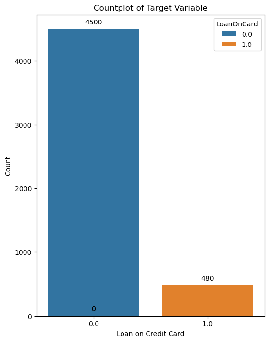

```python
# Visualize distribution of Target variable ‘LoanOnCard’ and clearly share insights.

plt.figure(figsize=(6,8))

# Create countplot
ax = sns.countplot(data=data,x=data['LoanOnCard'],hue='LoanOnCard')

# Add labels and title
ax.set(xlabel='Loan on Credit Card', ylabel='Count', title='Countplot of Target Variable')

# Add data labels on top of each bar
for p in ax.patches:
    ax.annotate(format(p.get_height(), '.0f'),
                (p.get_x() + p.get_width() / 2., p.get_height()),
                ha = 'center', va = 'center',
                xytext = (0, 10),
                textcoords = 'offset points')

# Show plot
plt.show()
```

**Observation: We can clearly see imbalanced class distribution from the above plot. Count is very high for Class'0', while it is very less for Class'1'.**

```python
# Check the percentage of missing values and impute if required.

# Calculate percentage of missing values in each column
percent_mv = data.isnull().sum() * 100 / len(data)
print(percent_mv)
```

```
ID                     0.0
Age                    0.0
CustomerSince          0.0
HighestSpend           0.0
ZipCode                0.0
HiddenScore            0.0
MonthlyAverageSpend    0.0
Level                  0.0
Mortgage               0.0
Security               0.0
FixedDepositAccount    0.0
InternetBanking        0.0
CreditCard             0.0
LoanOnCard             0.4
dtype: float64
```

**Observation: As the percentage of missing values in target variable 'LoanOnCard' is just 0.4%, we decide to impute the missing values with mode.**

```python
# Missing value imputation
mode_value = data['LoanOnCard'].mode()[0]
print(mode_value)
## Let's replace null values with mode_value
data['LoanOnCard']=data['LoanOnCard'].fillna(mode_value)
data.head()
```

```
0.0
```

|  | ID | Age | CustomerSince | HighestSpend | ZipCode | HiddenScore | MonthlyAverageSpend | Level | Mortgage | Security | FixedDepositAccount | InternetBanking | CreditCard | LoanOnCard |
| --- | --- | --- | --- | --- | --- | --- | --- | --- | --- | --- | --- | --- | --- | --- |
| 0 | 1 | 25 | 1 | 49 | 91107 | 4 | 1.6 | 1 | 0 | 1 | 0 | 0 | 0 | 0.0 |
| 1 | 2 | 45 | 19 | 34 | 90089 | 3 | 1.5 | 1 | 0 | 1 | 0 | 0 | 0 | 0.0 |
| 2 | 3 | 39 | 15 | 11 | 94720 | 1 | 1.0 | 1 | 0 | 0 | 0 | 0 | 0 | 0.0 |
| 3 | 4 | 35 | 9 | 100 | 94112 | 1 | 2.7 | 2 | 0 | 0 | 0 | 0 | 0 | 0.0 |
| 4 | 5 | 35 | 8 | 45 | 91330 | 4 | 1.0 | 2 | 0 | 0 | 0 | 0 | 1 | 0.0 |

```python
data.isnull().sum()
```

```
ID                     0
Age                    0
CustomerSince          0
HighestSpend           0
ZipCode                0
HiddenScore            0
MonthlyAverageSpend    0
Level                  0
Mortgage               0
Security               0
FixedDepositAccount    0
InternetBanking        0
CreditCard             0
LoanOnCard             0
dtype: int64
```

**Obervation: Now there is no missing values**

```python
data.info()
```

```
<class 'pandas.core.frame.DataFrame'>
RangeIndex: 5000 entries, 0 to 4999
Data columns (total 14 columns):
 #   Column               Non-Null Count  Dtype
---  ------               --------------  -----
 0   ID                   5000 non-null   int64
 1   Age                  5000 non-null   int64
 2   CustomerSince        5000 non-null   int64
 3   HighestSpend         5000 non-null   int64
 4   ZipCode              5000 non-null   int64
 5   HiddenScore          5000 non-null   object
 6   MonthlyAverageSpend  5000 non-null   float64
 7   Level                5000 non-null   object
 8   Mortgage             5000 non-null   int64
 9   Security             5000 non-null   object
 10  FixedDepositAccount  5000 non-null   object
 11  InternetBanking      5000 non-null   object
 12  CreditCard           5000 non-null   object
 13  LoanOnCard           5000 non-null   float64
dtypes: float64(2), int64(6), object(6)
memory usage: 547.0+ KB
```

```python
# Check for unexpected values in each categorical variable and impute with best suitable value.
print("Unique values of HiddenScore ",data['HiddenScore'].unique())
print("Unique values of Level ",data['Level'].unique())
print("Unique values of Security ",data['Security'].unique())
print("Unique values of FixedDepositAccount ",data['FixedDepositAccount'].unique())
print("Unique values of InternetBanking ",data['InternetBanking'].unique())
```

```
Unique values of HiddenScore  ['4' '3' '1' '2']
Unique values of Level  ['1' '2' '3']
Unique values of Security  ['1' '0']
Unique values of FixedDepositAccount  ['0' '1']
Unique values of InternetBanking  ['0' '1']
```

**Obervation: Now there are no unexpected values in each categorical variable**

### 3. DATA PREPARATION AND MODEL BUILDING

```python
# defining a function to compute different metrics to check performance of a classification model built using statsmodels
def model_performance_classification_sklearn(
    model, predictors, target, threshold=0.5
):
    """
    Function to compute different metrics to check classification model performance

    model: classifier
    predictors: independent variables
    target: dependent variable
    threshold: threshold for classifying the observation as class 1
    """

    # checking which probabilities are greater than threshold
    pred_temp = (model.predict_proba(predictors))[:, 1] > threshold
    # rounding off the above values to get classes
    pred = np.round(pred_temp)

    acc = accuracy_score(target, pred)  # to compute Accuracy
    recall = recall_score(target, pred)  # to compute Recall
    precision = precision_score(target, pred)  # to compute Precision
    f1 = f1_score(target, pred)  # to compute F1-score

    # creating a dataframe of metrics
    df_perf = pd.DataFrame(
        {"Accuracy": acc, "Recall": recall, "Precision": precision, "F1": f1,},
        index=[0],
    )

    return df_perf
```

```python
# defining a function to plot the confusion_matrix of a classification model


def confusion_matrix_sklearn(model, predictors, target, threshold=0.5):
    """
    To plot the confusion_matrix with percentages

    model: classifier
    predictors: independent variables
    target: dependent variable
    threshold: threshold for classifying the observation as class 1
    """
    # checking which probabilities are greater than threshold
    pred_temp = (model.predict_proba(predictors))[:, 1] > threshold
    # rounding off the above values to get classes
    y_pred = np.round(pred_temp)

    cm = confusion_matrix(target, y_pred)
    labels = np.asarray(
        [
            ["{0:0.0f}".format(item) + "\n{0:.2%}".format(item / cm.flatten().sum())]
            for item in cm.flatten()
        ]
    ).reshape(2, 2)

    plt.figure(figsize=(6, 4))
    sns.heatmap(cm, annot=labels, fmt="")
    plt.ylabel("True label")
    plt.xlabel("Predicted label")
```

```python
# Split data into X and Y.

X = data.drop(labels=['ID', 'ZipCode', 'LoanOnCard'], axis=1)
y = data['LoanOnCard']
```

```python
# Split data into train and test. Keep 25% data reserved for testing.

X_train, X_test, y_train, y_test = train_test_split(X, y, test_size=0.25, random_state=365)
```

```python
# Train a Supervised Learning Classification base model - Logistic Regression.

lr = LogisticRegression(solver="newton-cg", random_state=1)
lr.fit(X_train, y_train)
```

```
LogisticRegression(random_state=1, solver='newton-cg')
```

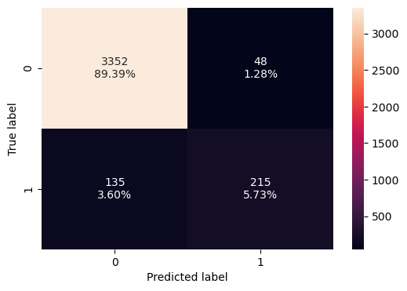

```python
confusion_matrix_sklearn(lr, X_train, y_train)
```

```python
# checking model performance for this model
log_reg_model_train_perf = model_performance_classification_sklearn(
    lr, X_train, y_train
)
print("Training performance:")
log_reg_model_train_perf
```

```
Training performance:
```

|  | Accuracy | Recall | Precision | F1 |
| --- | --- | --- | --- | --- |
| 0 | 0.9512 | 0.614286 | 0.81749 | 0.701468 |

```python
predicted=lr.predict(X_test)
```

```python
# checking model performance for this model
log_reg_model_test_perf = model_performance_classification_sklearn(
    lr, X_test, y_test
)
print("Test performance:")
log_reg_model_test_perf
```

```
Test performance:
```

|  | Accuracy | Recall | Precision | F1 |
| --- | --- | --- | --- | --- |
| 0 | 0.948 | 0.6 | 0.857143 | 0.705882 |

```python
print('Classification Report:  \n',classification_report(y_test, predicted))
```

```
Classification Report:
               precision    recall  f1-score   support

         0.0       0.96      0.99      0.97      1120
         1.0       0.86      0.60      0.71       130

    accuracy                           0.95      1250
   macro avg       0.91      0.79      0.84      1250
weighted avg       0.94      0.95      0.94      1250
```

```python
print('ROC_AUC score:', roc_auc_score(y_test, predicted).round(2))
```

```
ROC_AUC score: 0.79
```

**Observation:**

> **The model has a low recall on the training and test sets.**

> **Though the accuracy is 95%, the recall of minority class is very less. So we can say that our model is biased towards majority class.**

```python
# Check the distribution of the target variable
percent_dist_tv = (data.LoanOnCard.value_counts()/data.LoanOnCard.value_counts().sum())*100
percent_dist_tv
```

```
LoanOnCard
0.0    90.4
1.0     9.6
Name: count, dtype: float64
```

**Observations :**

> **We can see imbalanced distribution of classes in the target variable.**

> **90.4% belong to class'0.0' and 9.6% belong to class'1.0'.**

> **To overcome this problem we will use oversampling technique called SMOTE.**

```python
# balance the target variable as 50:50

from imblearn.over_sampling import SMOTE
smote = SMOTE()
X_train_res, y_train_res = smote.fit_resample(X_train, y_train)
```

```python
y_train_res.value_counts()
```

```
LoanOnCard
0.0    3400
1.0    3400
Name: count, dtype: int64
```

**Thus, we have balanced the target variable as 50:50.**

```python
lr.fit(X_train_res,y_train_res)
```

```
LogisticRegression(random_state=1, solver='newton-cg')
```

```python
# Print evaluation metrics and clearly share differences observed.
# checking model performance for this model
log_reg_model_train_perf = model_performance_classification_sklearn(
    lr, X_train_res, y_train_res
)
print("Training performance:")
log_reg_model_train_perf
```

```
Training performance:
```

|  | Accuracy | Recall | Precision | F1 |
| --- | --- | --- | --- | --- |
| 0 | 0.907353 | 0.913824 | 0.902149 | 0.907949 |

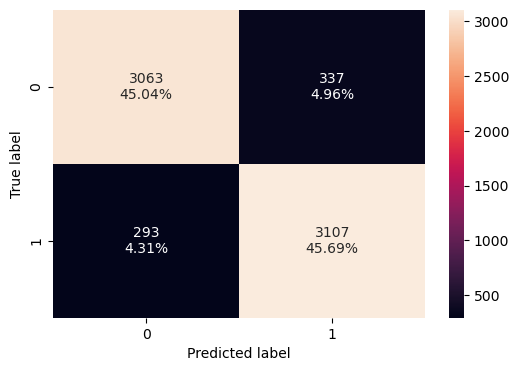

```python
confusion_matrix_sklearn(lr, X_train_res, y_train_res)
```

```python
predicted_res=lr.predict(X_test)
```

```python
# checking model performance for this model
log_reg_model_test_perf = model_performance_classification_sklearn(
    lr, X_test, y_test
)
print("Test performance:")
log_reg_model_test_perf
```

```
Test performance:
```

|  | Accuracy | Recall | Precision | F1 |
| --- | --- | --- | --- | --- |
| 0 | 0.9112 | 0.861538 | 0.546341 | 0.668657 |

```python
print('Classification Report:  \n', classification_report(y_test, predicted_res))
print('\n')
print('ROC_AUC score:', roc_auc_score(y_test, predicted_res).round(2))
```

```
Classification Report:
               precision    recall  f1-score   support

         0.0       0.98      0.92      0.95      1120
         1.0       0.55      0.86      0.67       130

    accuracy                           0.91      1250
   macro avg       0.76      0.89      0.81      1250
weighted avg       0.94      0.91      0.92      1250



ROC_AUC score: 0.89
```

**Observations:**

> **The accuracy has decreased a little bit, but the recall score has increased for the minority class.**

> **ROC_AUC score has improved from 0.79 to 0.89.**

### 4. PERFORMANCE IMPROVEMENT

```python
#Train a base model each for SVM
svm_base = SVC(probability=True,random_state=42)
svm_base.fit(X_train,y_train)
```

```
SVC(probability=True, random_state=42)
```

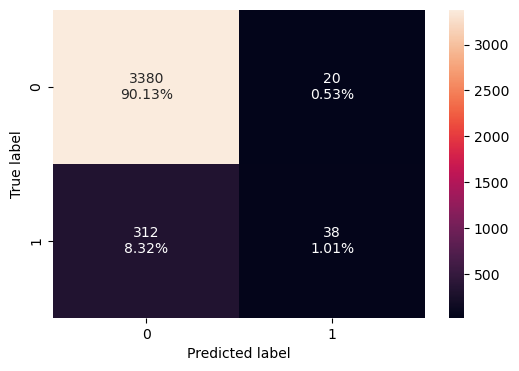

```python
confusion_matrix_sklearn(svm_base, X_train, y_train)
```

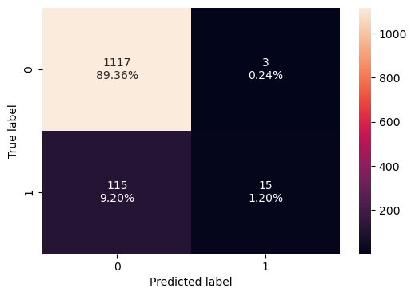

```python
confusion_matrix_sklearn(model=svm_base,predictors= X_test, target=y_test)
```

```python
print("Training performance:")
model_lin_kern = model_performance_classification_sklearn(model=svm_base, predictors=X_train, target=y_train)
model_lin_kern
```

```
Training performance:
```

|  | Accuracy | Recall | Precision | F1 |
| --- | --- | --- | --- | --- |
| 0 | 0.911467 | 0.108571 | 0.655172 | 0.186275 |

```python
print("Test performance:")
model_lin_kern_test = model_performance_classification_sklearn(model=svm_base, predictors=X_test, target=y_test)
model_lin_kern_test
```

```
Test performance:
```

|  | Accuracy | Recall | Precision | F1 |
| --- | --- | --- | --- | --- |
| 0 | 0.9056 | 0.115385 | 0.833333 | 0.202703 |

**Observation: We can see from performance report that Accuracy and Precision is high but Recall and F1 score is quite low**

```python
# Tune parameters for each of the models wherever required and finalize a model.

# Tune parameters for svm model with default kernel 'rbf' using different values of 'C' and 'gamma'
c_values = []
gamma_values = []
accuracy = []
precision = []
recall = []
f1_score_list = []

C = [0.001,0.01,0.1,1,100,1000]
gamma = [0.001,0.01,0.1,1,100,1000]
for i in C:
    for j in gamma:
        svm_model = SVC(C=i, gamma=j,probability=True,random_state=42)
        svm_model.fit(X_train, y_train)
        pred = svm_model.predict(X_test)
        c_values.append(i)
        gamma_values.append(j)
        accuracy.append(accuracy_score(y_test,pred))
        precision.append(precision_score(y_test,pred, zero_division=0))
        recall.append(recall_score(y_test,pred))
        f1_score_list.append(f1_score(y_test, pred))
```

```python
# Create a score table with different values of 'C' and 'gamma'

d = {'C': c_values, 'Gamma': gamma_values, 'Accuracy': accuracy, 'Precision': precision, 'Recall': recall, 'f1-score': f1_score_list}
df_performance=pd.DataFrame(data=d)
df_performance
```

|  | C | Gamma | Accuracy | Precision | Recall | f1-score |
| --- | --- | --- | --- | --- | --- | --- |
| 0 | 0.001 | 0.001 | 0.8960 | 0.000000 | 0.000000 | 0.000000 |
| 1 | 0.001 | 0.010 | 0.8960 | 0.000000 | 0.000000 | 0.000000 |
| 2 | 0.001 | 0.100 | 0.8960 | 0.000000 | 0.000000 | 0.000000 |
| 3 | 0.001 | 1.000 | 0.8960 | 0.000000 | 0.000000 | 0.000000 |
| 4 | 0.001 | 100.000 | 0.8960 | 0.000000 | 0.000000 | 0.000000 |
| 5 | 0.001 | 1000.000 | 0.8960 | 0.000000 | 0.000000 | 0.000000 |
| 6 | 0.010 | 0.001 | 0.8960 | 0.000000 | 0.000000 | 0.000000 |
| 7 | 0.010 | 0.010 | 0.8960 | 0.000000 | 0.000000 | 0.000000 |
| 8 | 0.010 | 0.100 | 0.8960 | 0.000000 | 0.000000 | 0.000000 |
| 9 | 0.010 | 1.000 | 0.8960 | 0.000000 | 0.000000 | 0.000000 |
| 10 | 0.010 | 100.000 | 0.8960 | 0.000000 | 0.000000 | 0.000000 |
| 11 | 0.010 | 1000.000 | 0.8960 | 0.000000 | 0.000000 | 0.000000 |
| 12 | 0.100 | 0.001 | 0.8960 | 0.000000 | 0.000000 | 0.000000 |
| 13 | 0.100 | 0.010 | 0.8960 | 0.000000 | 0.000000 | 0.000000 |
| 14 | 0.100 | 0.100 | 0.8960 | 0.000000 | 0.000000 | 0.000000 |
| 15 | 0.100 | 1.000 | 0.8960 | 0.000000 | 0.000000 | 0.000000 |
| 16 | 0.100 | 100.000 | 0.8960 | 0.000000 | 0.000000 | 0.000000 |
| 17 | 0.100 | 1000.000 | 0.8960 | 0.000000 | 0.000000 | 0.000000 |
| 18 | 1.000 | 0.001 | 0.9064 | 0.724138 | 0.161538 | 0.264151 |
| 19 | 1.000 | 0.010 | 0.9088 | 0.807692 | 0.161538 | 0.269231 |
| 20 | 1.000 | 0.100 | 0.8960 | 0.500000 | 0.015385 | 0.029851 |
| 21 | 1.000 | 1.000 | 0.8960 | 0.000000 | 0.000000 | 0.000000 |
| 22 | 1.000 | 100.000 | 0.8960 | 0.000000 | 0.000000 | 0.000000 |
| 23 | 1.000 | 1000.000 | 0.8960 | 0.000000 | 0.000000 | 0.000000 |
| 24 | 100.000 | 0.001 | 0.9568 | 0.865385 | 0.692308 | 0.769231 |
| 25 | 100.000 | 0.010 | 0.9456 | 0.822917 | 0.607692 | 0.699115 |
| 26 | 100.000 | 0.100 | 0.9000 | 0.608696 | 0.107692 | 0.183007 |
| 27 | 100.000 | 1.000 | 0.8960 | 0.000000 | 0.000000 | 0.000000 |
| 28 | 100.000 | 100.000 | 0.8960 | 0.000000 | 0.000000 | 0.000000 |
| 29 | 100.000 | 1000.000 | 0.8960 | 0.000000 | 0.000000 | 0.000000 |
| 30 | 1000.000 | 0.001 | 0.9592 | 0.869159 | 0.715385 | 0.784810 |
| 31 | 1000.000 | 0.010 | 0.9448 | 0.842697 | 0.576923 | 0.684932 |
| 32 | 1000.000 | 0.100 | 0.9000 | 0.608696 | 0.107692 | 0.183007 |
| 33 | 1000.000 | 1.000 | 0.8960 | 0.000000 | 0.000000 | 0.000000 |
| 34 | 1000.000 | 100.000 | 0.8960 | 0.000000 | 0.000000 | 0.000000 |
| 35 | 1000.000 | 1000.000 | 0.8960 | 0.000000 | 0.000000 | 0.000000 |

**Observation: From the above dataframe, we can say that the SVM model with C=1000 and gamma=0.001 gives the highest accuracy, precision, recall and f1 score.**

```python
#Train data with KNN Model
from sklearn.neighbors import KNeighborsClassifier
KNN = KNeighborsClassifier(n_neighbors= 3) #Building knn with 3 neighbors
KNN.fit(X_train, y_train)
```

```
KNeighborsClassifier(n_neighbors=3)
```

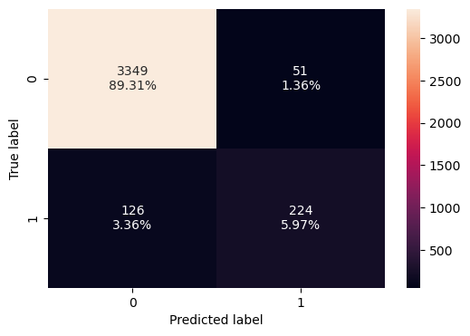

```python
confusion_matrix_sklearn(KNN, X_train, y_train)
```

```python
print("Training performance:")
model_knn = model_performance_classification_sklearn(model=KNN, predictors=X_train, target=y_train)
model_knn
```

```
Training performance:
```

|  | Accuracy | Recall | Precision | F1 |
| --- | --- | --- | --- | --- |
| 0 | 0.9528 | 0.64 | 0.814545 | 0.7168 |

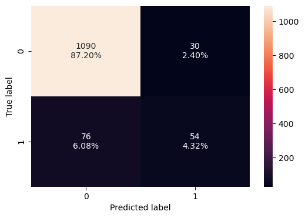

```python
confusion_matrix_sklearn(KNN, X_test, y_test)
```

```python
print("Test performance:")
model_knn_test = model_performance_classification_sklearn(model=KNN, predictors=X_test, target=y_test)
model_knn_test
```

```
Test performance:
```

|  | Accuracy | Recall | Precision | F1 |
| --- | --- | --- | --- | --- |
| 0 | 0.9152 | 0.415385 | 0.642857 | 0.504673 |

**Observation : We can see accuracny is high but Recall and Precision and F1 score are very low**

```python
# Tune parameters of the knn model
# train_score=[]
# test_score=[]
accuracy_knn = []
precision_knn = []
recall_knn = []
f1_score_knn = []
n_neighbors_param = []

neighbors = [i for i in range(1,51) if i%2 != 0]
for k in neighbors:
    KNN = KNeighborsClassifier(n_neighbors= k )
    KNN.fit(X_train, y_train)
    pred_knn = KNN.predict(X_test)
    n_neighbors_param.append(k)
      # predict on train and test
    accuracy_knn.append(accuracy_score(y_test,pred_knn))
    precision_knn.append(precision_score(y_test,pred_knn))
    recall_knn.append(recall_score(y_test,pred_knn))
    f1_score_knn.append(f1_score(y_test,pred_knn))
```

```python
# Create a score table with different values of 'K'

p = {'neighbors-Value': n_neighbors_param, 'Accuracy': accuracy_knn, 'Precision': precision_knn, 'Recall': recall_knn, 'f1-score': f1_score_knn}
knn_perofrmance_matrix=pd.DataFrame(data=p)
knn_perofrmance_matrix
```

|  | neighbors-Value | Accuracy | Precision | Recall | f1-score |
| --- | --- | --- | --- | --- | --- |
| 0 | 1 | 0.9072 | 0.576087 | 0.407692 | 0.477477 |
| 1 | 3 | 0.9152 | 0.642857 | 0.415385 | 0.504673 |
| 2 | 5 | 0.9080 | 0.602740 | 0.338462 | 0.433498 |
| 3 | 7 | 0.9096 | 0.626866 | 0.323077 | 0.426396 |
| 4 | 9 | 0.9096 | 0.639344 | 0.300000 | 0.408377 |
| 5 | 11 | 0.9096 | 0.654545 | 0.276923 | 0.389189 |
| 6 | 13 | 0.9032 | 0.576271 | 0.261538 | 0.359788 |
| 7 | 15 | 0.9048 | 0.593220 | 0.269231 | 0.370370 |
| 8 | 17 | 0.9056 | 0.615385 | 0.246154 | 0.351648 |
| 9 | 19 | 0.9032 | 0.581818 | 0.246154 | 0.345946 |
| 10 | 21 | 0.9048 | 0.607843 | 0.238462 | 0.342541 |
| 11 | 23 | 0.9016 | 0.574468 | 0.207692 | 0.305085 |
| 12 | 25 | 0.9056 | 0.625000 | 0.230769 | 0.337079 |
| 13 | 27 | 0.9040 | 0.608696 | 0.215385 | 0.318182 |
| 14 | 29 | 0.9056 | 0.642857 | 0.207692 | 0.313953 |
| 15 | 31 | 0.9048 | 0.677419 | 0.161538 | 0.260870 |
| 16 | 33 | 0.9040 | 0.666667 | 0.153846 | 0.250000 |
| 17 | 35 | 0.9024 | 0.642857 | 0.138462 | 0.227848 |
| 18 | 37 | 0.9008 | 0.615385 | 0.123077 | 0.205128 |
| 19 | 39 | 0.9048 | 0.720000 | 0.138462 | 0.232258 |
| 20 | 41 | 0.9032 | 0.666667 | 0.138462 | 0.229299 |
| 21 | 43 | 0.9024 | 0.666667 | 0.123077 | 0.207792 |
| 22 | 45 | 0.9024 | 0.666667 | 0.123077 | 0.207792 |
| 23 | 47 | 0.9024 | 0.700000 | 0.107692 | 0.186667 |
| 24 | 49 | 0.9024 | 0.750000 | 0.092308 | 0.164384 |

**Observation:**

**On comparing the SVM and KNN model, the SVM model is the best as it gives the highest accuracy, precision, recall and f1 score. Hence our final model is the SVM model with C=1000 and gamma=0.001.**

```python
# Print evaluation metrics for final model.

svm_final = SVC(C=1000, gamma=0.001,probability=True,random_state=42)
svm_final.fit(X_train, y_train)
```

```
SVC(C=1000, gamma=0.001, probability=True, random_state=42)
```

```python
pred_final = svm_final.predict(X_test)
print('Classification Report of the final model: \n', metrics.classification_report(y_test, pred_final))
print('\n')
print('ROC_AUC Score of the final model:', metrics.roc_auc_score(y_test, pred_final).round(2))
```

```
Classification Report of the final model:
               precision    recall  f1-score   support

         0.0       0.97      0.99      0.98      1120
         1.0       0.87      0.72      0.78       130

    accuracy                           0.96      1250
   macro avg       0.92      0.85      0.88      1250
weighted avg       0.96      0.96      0.96      1250



ROC_AUC Score of the final model: 0.85
```

```python
# Peformance of svm base model
pred_base = svm_base.predict(X_test)
```

```python
print('Classification Report of the svm base model: \n', metrics.classification_report(y_test, pred_base))
print('\n')
print('ROC_AUC Score of the svm base model:', metrics.roc_auc_score(y_test, pred_base).round(2))
```

```
Classification Report of the svm base model:
               precision    recall  f1-score   support

         0.0       0.91      1.00      0.95      1120
         1.0       0.82      0.11      0.19       130

    accuracy                           0.90      1250
   macro avg       0.86      0.55      0.57      1250
weighted avg       0.90      0.90      0.87      1250



ROC_AUC Score of the svm base model: 0.55
```

**Improvements achieved:**

> **Accuracy increased from 0.90 to 0.96.**

> **Precision, Recall and f1-score has increased in the final model.**

> **ROC_AUC score has improved from 0.55 to 0.85.**